# Autocratization and Survey Experiments

Jeremy Springman

University of Pennsylvania

**Global Development**: Intermediate Topics in Politics, Policy, and Data

PSCI 3200 - Spring 2025

# Logistics

## Assignments

- Today
  - 3 readings
  - Ensure Quarto is installed
- Thursday
  - Create a git repo for this class (psci3200_yourname)
  - DSS Ch4

## Agenda

1. Finishing up Final Project
2. RStudio and Quarto
3. Survey Experiments
   1. Overview
   2. Albertus & Grossman
   3. Hollerbauer et al.

# Final Project

## Examples of research questions

- Do citizens with mobile internet access have more negative opinions about their government?
- Do citizens that migrate have more or less positive views about democracy?
- Are domestic media outlets less likely to report on political events after elections?

# RStudio and Quarto

## Poll

- Mac vs Windows vs Other?
- Quarto running?

## Instructions

- Follow-along as I create a quarto page
- Submit the html for the page to me via Slack *before* the end of class

# Survey Experiments

## What are survey experiments?

**Two general uses**

- Measuring sensitive attitudes
  - Providing anonymity
- Identifying causal effect
  - Manipulating images and text

## List Experiments

- What can list experiments tell us?
  - prevalence of the sensitive attitude in the survey population
- What can they *not* tell us
  - attitude of any individual respondent
- When might this be useful?
  - Assessing prevalence of something
  - Quantifying measurement bias/misreporting

## List Experiments

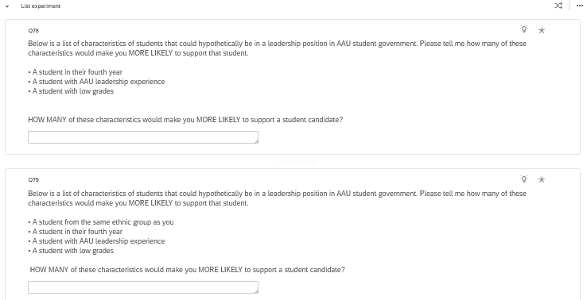

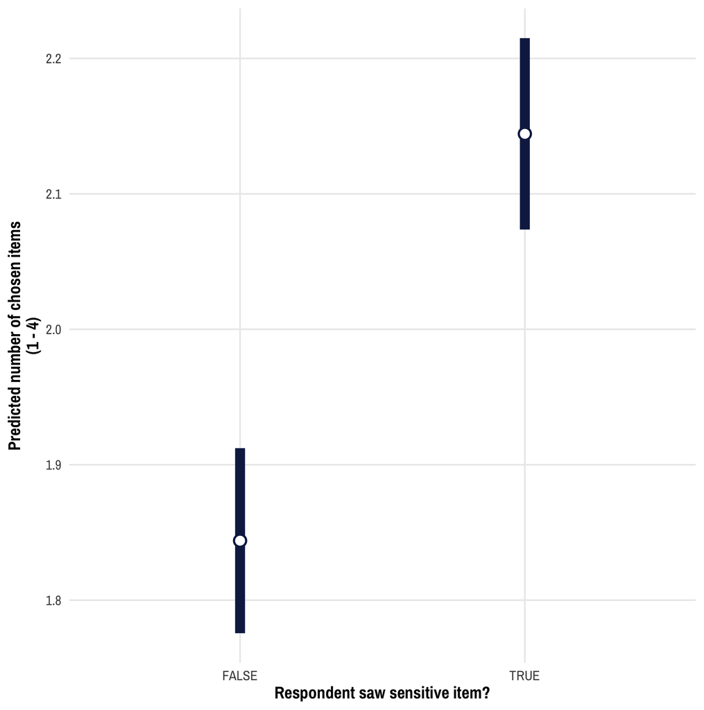

## Randomized Response

- What is it?
  - Induce some $p > 0$ that you say “Yes” even if you disagree
- Pitfalls
  - Complexity, confusion
  - Lack of anonymity
- Variants
  - Repeated randomized response
  - Crosswise

## Priming

- What is it?
  - Measures *implicit* attitudes by stimulating unconscious association
- Pitfalls
  - Hard to know if the prime worked (false negative, confounding, etc.)

## Vignettes and Factorials

- What is it?
  - Presents a scenario while varying key components
- Pitfalls
  - Unrealistic combinations
  - Limited power

## Conjoints

- What is it?
  - Presents pair of profiles while varying attributes
  - Asks respondents to choose between profiles
- Pitfalls
  - Requires careful attention
  - Can be highly synthetic

# Albertus & Grossman

## Background

**Decline in the quantity and quality of democracies**

- Executive power grabs rather than coups
1. Weaken judiciary and media independence
2. Purge bureaucracy and neutralize legislature
3. Reduce political competition through legal changes

## Research Questions

1. Why do many voters support or ignore antidemocratic actions?
2. Why are transgressions rarely punished?
3. How is public opinion affected by means and justification?

## Research Question

**Why don’t citizens resist?**

- Citizens don’t realize
  - Should identify and oppose
- Citizens are conditional democrats (trade-off w/ideology)
  - Should identify and support conditional on ideology
- Citizens may have differing conceptions of democracy
  - Don’t identify as antidemocratic

## What’s the Research Design?

**Vignette Experiment**

- Manipulation
  - Antidemocratic behavior
  - Partisan alignment
  - Means and justifications
- Outcomes
  - Perceived as antidemocratic
  - Support for action
  - Support for punishment

## Findings

- Positive
  - Respondents identify antidemocratic actions and oppose them
  - Means and justifications do not increase support
- Negative
  - Significant minority supports antidemocratic actions
  - Partisan power increases support

## Editorial Notes

Pushes back against polarization based explanations, which predict that people *support* antidemocratic behaviors because they view the other side as so dangerous

## Policy Implications?

- Normalize punishment
- Emphasize long-run risks

# Hollerbauer

jrspringman.github.io/psci3200-globaldev/